# MachineLearning avance_Zahira_Sophie-Vendredi12h (1)

### 1.1.1 Régression Logistique avec régularisation Ridge et recherche du meilleur paramètre de régularisation

```python
#Import des librairies

from sklearn.model_selection import GridSearchCV
from sklearn.linear_model import LogisticRegression
from sklearn.metrics import confusion_matrix

#Entrainement du modèle avec Gridsearch.
#Gridsearch permet de faire une recherche exhaustive sur les valeurs de paramètres spécifiées pour un estimateur.
#Les paramètres de l'estimateur utilisé pour appliquer ces méthodes sont optimisés par une recherche croisée validée sur une grille de paramètres.
#On fait une validation croisée égale à 5.


model = LogisticRegression(penalty='l2')
# Le choix est porté sur la classification à l'aide de la régression logistique avec régularisation : norme l2 (Ridge)
grid_values = {'C': [0.001,0.01,0.1,1,10, 100]}
grid = GridSearchCV(model, param_grid = grid_values, scoring = 'accuracy',cv=5).fit(X_train, y_train)
print("Classification Ridge: ",y_train," Meilleur paramètre=",grid.best_params_)
print("Accuracy sur la base d'entrainement:",round(grid.score(X_train,y_train),5)," ",\
      "Accuracy sur la base de test:",round(grid.score(X_test,y_test),5),"\n")
```

```
Classification Ridge:  [1. 0. 0. ... 1. 0. 0.]  Meilleur paramètre= {'C': 0.001}
Accuracy sur la base d'entrainement: 1.0   Accuracy sur la base de test: 1.0
```

```python
result=pd.DataFrame(grid.cv_results_)
result
```

|  | mean_fit_time | std_fit_time | mean_score_time | std_score_time | param_C | params | split0_test_score | split1_test_score | split2_test_score | split3_test_score | split4_test_score | mean_test_score | std_test_score | rank_test_score |
| --- | --- | --- | --- | --- | --- | --- | --- | --- | --- | --- | --- | --- | --- | --- |
| 0 | 0.389682 | 0.143615 | 0.037327 | 0.053712 | 0.001 | {'C': 0.001} | 1.0 | 1.0 | 1.0 | 1.0 | 1.0 | 1.0 | 0.0 | 1 |
| 1 | 0.342274 | 0.001924 | 0.010373 | 0.000797 | 0.01 | {'C': 0.01} | 1.0 | 1.0 | 1.0 | 1.0 | 1.0 | 1.0 | 0.0 | 1 |
| 2 | 0.354851 | 0.008426 | 0.010372 | 0.001017 | 0.1 | {'C': 0.1} | 1.0 | 1.0 | 1.0 | 1.0 | 1.0 | 1.0 | 0.0 | 1 |
| 3 | 0.360037 | 0.013878 | 0.010174 | 0.000747 | 1 | {'C': 1} | 1.0 | 1.0 | 1.0 | 1.0 | 1.0 | 1.0 | 0.0 | 1 |
| 4 | 0.350463 | 0.004211 | 0.009176 | 0.000399 | 10 | {'C': 10} | 1.0 | 1.0 | 1.0 | 1.0 | 1.0 | 1.0 | 0.0 | 1 |
| 5 | 0.350263 | 0.005477 | 0.009575 | 0.000489 | 100 | {'C': 100} | 1.0 | 1.0 | 1.0 | 1.0 | 1.0 | 1.0 | 0.0 | 1 |

#### Commentaire:

Le meilleur paramètre de régularisation Ridge est 0.001, pour voir le nombre de features selectionnées ainsi que leur importance

#### Analyse des features les plus importants dans la construction du modèle

```python
# Sélection de features les plus importants ( plus significatives) dans la construction du modèle
from sklearn.feature_selection import SelectFromModel

estimator = LogisticRegression(penalty='l2',C=0.001).fit(X_train,y_train)
model = SelectFromModel(estimator, prefit=True)
model.estimator.coef_[0]
index=model.get_support(indices=True)

print('Nombre de features selectionés  ' +  str(len(index)))
coef=model.estimator.coef_[0]
features=[]
estimation=[]
indice=[]
for i in range (0, len(index)):
    features.append(colnames[index[i]])
    estimation.append(abs(coef[index[i]]))
    indice.append(index[i])
```

```
Nombre de features selectionés  155
```

```python
dataset = list(zip(indice,features,estimation))
feature_importance=pd.DataFrame(data=dataset, columns=['indice','features','coef'])
sorted_feat=feature_importance.sort_values(by=['coef'], ascending=False)
print('Les features les plus importantes pour le modèle regression Logistique Ridge')
sorted_feat
```

```
Les features les plus importantes pour le modèle regression Logistique Ridge
```

|  | indice | features | coef |
| --- | --- | --- | --- |
| 6 | 7 | h | 0.066736 |
| 19 | 20 | u | 0.039377 |
| 128 | 527 | th | 0.038450 |
| 3 | 4 | e | 0.032335 |
| 13 | 14 | o | 0.032324 |
| ... | ... | ... | ... |
| 38 | 88 | ck | 0.002028 |
| 93 | 377 | nn | 0.002023 |
| 68 | 196 | go | 0.001965 |
| 97 | 390 | oa | 0.001964 |
| 36 | 76 | by | 0.001960 |

155 rows × 3 columns

#### Commentaire :

- Les features h, u et th et e sont les features les plus importants dans la construction du modèle.

```python
#Matrice de confusion
conf_mat=confusion_matrix(y_test, grid.predict(X_test))
```

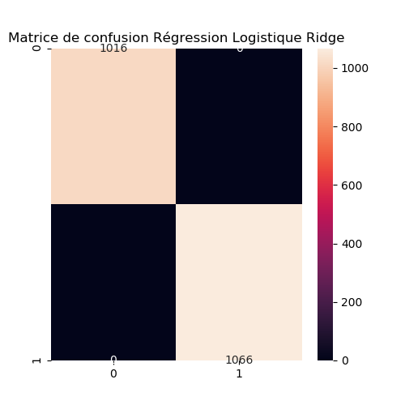

```python
import seaborn as sns
fig, _ = plt.subplots(figsize=(5, 5))
plt.title('Matrice de confusion Régression Logistique Ridge');
sns.heatmap(conf_mat, annot=True,  fmt='')
```

#### Visualisation de la frontière de séparation des classes sur base des features les plus importants

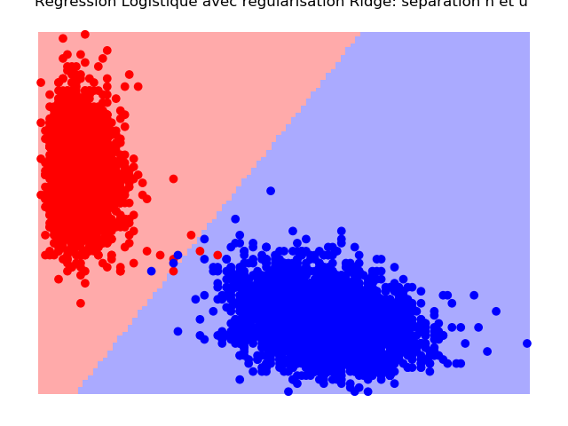

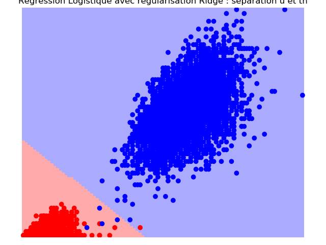

```python
#features 'h' et 'u'
X1 = X[:,[7,20]]
y = y

#Appel à la fonction plot pour visualiser la frontière de séparation
plot_estimator(grid,X1,y)
plt.title('Regression Logistique avec régularisation Ridge: separation h et u ')
X2 = X[:,[7,527]]  # Features : u et th
plot_estimator(grid,X2,y)
plt.title('Regression Logistique avec régularisation Ridge : separation u et th')
```

### Commentaires :

La regréssion Logistique avec normalisation Ridge permet de faire une classification 100% exacte. En effet, toutes les instances de la base de test ont été correctement classées.

### 1.1.2 Régression Logistique avec régularisation Lasso

- Test du classification d'une régression logistique avec une régularisation lasso
- Recherche du meilleur paramètre de régularisation
- Validation croisée sur 5
- La performance sera mesurée avec le niveau d'accuracy ratio et la frontière de décision
- Définition de la matrice de confusion

```python
model = LogisticRegression(penalty='l1') # norme l1 pour la normalisation Lasso

grid_values = {'C': [0.001, 0.01,0.1,1,10, 100, 1000]}
grid = GridSearchCV(model, param_grid = grid_values, scoring = 'accuracy', cv=5).fit(X_train, y_train)
print("Classification Lasso: ",y_train," Meilleur paramètre=",grid.best_params_)
print("Accuracy sur la base d'entrainement:",round(grid.score(X_train,y_train),5)," ",\
      "Accuracy sur la base de test:",round(grid.score(X_test,y_test),5),"\n")
```

```
Classification Lasso:  [1. 0. 0. ... 1. 0. 0.]  Meilleur paramètre= {'C': 0.1}
Accuracy sur la base d'entrainement: 1.0   Accuracy sur la base de test: 1.0
```

```python
result=pd.DataFrame(grid.cv_results_)
result
```

|  | mean_fit_time | std_fit_time | mean_score_time | std_score_time | param_C | params | split0_test_score | split1_test_score | split2_test_score | split3_test_score | split4_test_score | mean_test_score | std_test_score | rank_test_score |
| --- | --- | --- | --- | --- | --- | --- | --- | --- | --- | --- | --- | --- | --- | --- |
| 0 | 0.265132 | 0.017743 | 0.011705 | 0.003166 | 0.001 | {'C': 0.001} | 1.0 | 1.0 | 1.0 | 0.999199 | 0.999199 | 0.99968 | 0.000393 | 6 |
| 1 | 0.262169 | 0.008098 | 0.009306 | 0.000843 | 0.01 | {'C': 0.01} | 1.0 | 1.0 | 1.0 | 0.999199 | 0.999199 | 0.99968 | 0.000393 | 6 |
| 2 | 0.278455 | 0.005931 | 0.009176 | 0.000746 | 0.1 | {'C': 0.1} | 1.0 | 1.0 | 1.0 | 1.000000 | 1.000000 | 1.00000 | 0.000000 | 1 |
| 3 | 0.282444 | 0.007710 | 0.009576 | 0.000489 | 1 | {'C': 1} | 1.0 | 1.0 | 1.0 | 1.000000 | 1.000000 | 1.00000 | 0.000000 | 1 |
| 4 | 0.307771 | 0.007887 | 0.009576 | 0.000487 | 10 | {'C': 10} | 1.0 | 1.0 | 1.0 | 1.000000 | 1.000000 | 1.00000 | 0.000000 | 1 |
| 5 | 0.300396 | 0.006414 | 0.009376 | 0.000489 | 100 | {'C': 100} | 1.0 | 1.0 | 1.0 | 1.000000 | 1.000000 | 1.00000 | 0.000000 | 1 |
| 6 | 0.293791 | 0.012475 | 0.009575 | 0.000488 | 1000 | {'C': 1000} | 1.0 | 1.0 | 1.0 | 1.000000 | 1.000000 | 1.00000 | 0.000000 | 1 |

#### Commentaire:

Le meilleur paramètre de régularisation Lasso est 0.1, pour voir le nombre de features selectionnées ainsi que leur importance

```python
#Matrice de confusion
conf_mat=confusion_matrix(y_test, grid.predict(X_test))
```

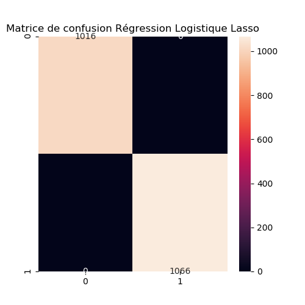

```python
import seaborn as sns
fig, _ = plt.subplots(figsize=(5, 5))
plt.title('Matrice de confusion Régression Logistique Lasso');
sns.heatmap(conf_mat, annot=True,  fmt='')
```

#### Identification des features les plus importantes pour la regression lasso

```python
#Nous utilisons les hyperpamètres trouvés pour trouver les features les plus importants
estimator = LogisticRegression(penalty='l1',C=0.1).fit(X_train,y_train)
model = SelectFromModel(estimator, prefit=True)
#estimator=SelectFromModel(LogisticRegression(penalty='l1',C=0.1).fit(X_train,y_train), prefit=True)
model.estimator.coef_[0]
index=model.get_support(indices=True)

print('Nombre de features selectionees dans Regression logistique Lasso est ' +  str(len(index)))
coef=model.estimator.coef_[0]
features=[]
estimation=[]
indice=[]
for i in range (0, len(index)):
    features.append(colnames[index[i]])
    estimation.append(abs(coef[index[i]]))
    indice.append(index[i])
```

```
Nombre de features selectionees dans Regression logistique Lasso est 16
```

```python
dataset = list(zip(indice,features,estimation))
feature_importance=pd.DataFrame(data=dataset, columns=['indice','features','coef'])
sorted_feat=feature_importance.sort_values(by=['coef'], ascending=False)
print('Les features les plus importantes pour le modèle regression Logistique Lasso')
sorted_feat
```

```
Les features les plus importantes pour le modèle regression Logistique Lasso
```

|  | indice | features | coef |
| --- | --- | --- | --- |
| 15 | 527 | th | 0.145929 |
| 10 | 22 | w | 0.141577 |
| 2 | 7 | h | 0.104522 |
| 9 | 20 | u | 0.075555 |
| 11 | 24 | y | 0.063140 |
| 13 | 148 | es | 0.027446 |
| 14 | 316 | le | 0.024670 |
| 1 | 4 | e | 0.015856 |
| 5 | 14 | o | 0.012507 |
| 6 | 15 | p | 0.011946 |
| 3 | 8 | i | 0.009367 |
| 4 | 11 | l | 0.005649 |
| 8 | 18 | s | 0.004947 |
| 12 | 34 | ai | 0.002048 |
| 0 | 0 | a | 0.001892 |
| 7 | 17 | r | 0.001866 |

#### Commentaires :

Pour ce modèle de Regression Logistique Lasso, les 3 premiers variables les plus importantes dans le modèle sont th, w et h

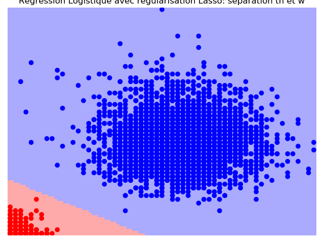

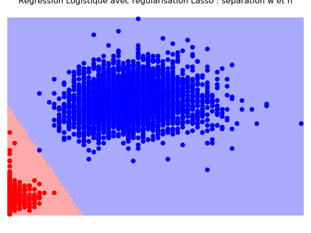

```python
X1 = X[:,[527,22]]  #features th et w

#Appel à la focntion plot pour visualiser la frontière de séparation
plot_estimator(grid,X1,y)
plt.title('Regression Logistique avec régularisation Lasso: separation th et w')
X2 = X[:,[22,7]]  # Features : w et h
plot_estimator(grid,X2,y)
plt.title('Regression Logistique avec régularisation Lasso : separation w et h')
```

La regréssion Logistique avec normalisation Lasso permet de faire une classification des deux classes de langue de manière 100% exacte.

### 1.1.3 Classificateur SVM Linéaire

```python
from sklearn.svm import SVC
from sklearn.svm import LinearSVC
svm = LinearSVC()
grid_values = {'C': [0.001, 0.01,0.1,1,10,100]}
grid = GridSearchCV(svm,param_grid = grid_values, scoring = 'accuracy', cv=5).fit(X_train, y_train)
print("Classification SVM linéaire: ",y_train," bestparam=",grid.best_params_)
print("Accuracy sur la base d'entrainement:",round(grid.score(X_train,y_train),5)," ",\
      "Accuracy sur la base de test:",round(grid.score(X_test,y_test),5),"\n")
```

```
Classification SVM linéaire:  [1. 0. 0. ... 1. 0. 0.]  bestparam= {'C': 0.001}
Accuracy sur la base d'entrainement: 1.0   Accuracy sur la base de test: 1.0
```

```python
result=pd.DataFrame(grid.cv_results_)
result
```

|  | mean_fit_time | std_fit_time | mean_score_time | std_score_time | param_C | params | split0_test_score | split1_test_score | split2_test_score | split3_test_score | split4_test_score | mean_test_score | std_test_score | rank_test_score |
| --- | --- | --- | --- | --- | --- | --- | --- | --- | --- | --- | --- | --- | --- | --- |
| 0 | 0.177590 | 0.013146 | 0.010900 | 2.062031e-03 | 0.001 | {'C': 0.001} | 1.0 | 1.0 | 1.0 | 1.0 | 1.0 | 1.0 | 0.0 | 1 |
| 1 | 0.192851 | 0.015539 | 0.009974 | 6.289914e-07 | 0.01 | {'C': 0.01} | 1.0 | 1.0 | 1.0 | 1.0 | 1.0 | 1.0 | 0.0 | 1 |
| 2 | 0.198669 | 0.021589 | 0.009375 | 4.872165e-04 | 0.1 | {'C': 0.1} | 1.0 | 1.0 | 1.0 | 1.0 | 1.0 | 1.0 | 0.0 | 1 |
| 3 | 0.175937 | 0.019353 | 0.009767 | 1.160698e-03 | 1 | {'C': 1} | 1.0 | 1.0 | 1.0 | 1.0 | 1.0 | 1.0 | 0.0 | 1 |
| 4 | 0.181115 | 0.023318 | 0.009576 | 4.877617e-04 | 10 | {'C': 10} | 1.0 | 1.0 | 1.0 | 1.0 | 1.0 | 1.0 | 0.0 | 1 |
| 5 | 0.193981 | 0.016199 | 0.010173 | 1.465350e-03 | 100 | {'C': 100} | 1.0 | 1.0 | 1.0 | 1.0 | 1.0 | 1.0 | 0.0 | 1 |

### Identification des features les plus importantes

```python
#Nous utilisons les hyperpamètres trouvés pour trouver les features les plus importants
estimator =LinearSVC(C=0.001).fit(X_train, y_train)
model = SelectFromModel(estimator, prefit=True)
#estimator=SelectFromModel(LogisticRegression(penalty='l1',C=0.1).fit(X_train,y_train), prefit=True)
model.estimator.coef_[0]
index=model.get_support(indices=True)

print('Nombre de features selectionees dans Regression logistique Lasso est ' +  str(len(index)))
coef=model.estimator.coef_[0]
features=[]
estimation=[]
indice=[]
for i in range (0, len(index)):
    features.append(colnames[index[i]])
    estimation.append(abs(coef[index[i]]))
    indice.append(index[i])
```

```
Nombre de features selectionees dans Regression logistique Lasso est 178
```

```python
dataset = list(zip(indice,features,estimation))
feature_importance=pd.DataFrame(data=dataset, columns=['indice','features','coef'])
sorted_feat=feature_importance.sort_values(by=['coef'], ascending=False)
print('Les features les plus importantes pour le modèle SVM lineaire')
sorted_feat
```

```
Les features les plus importantes pour le modèle SVM lineaire
```

|  | indice | features | coef |
| --- | --- | --- | --- |
| 6 | 7 | h | 0.010772 |
| 17 | 20 | u | 0.007715 |
| 19 | 22 | w | 0.007569 |
| 150 | 527 | th | 0.007042 |
| 21 | 24 | y | 0.006964 |
| ... | ... | ... | ... |
| 81 | 234 | ia | 0.000468 |
| 175 | 653 | yd | 0.000467 |
| 75 | 200 | gs | 0.000466 |
| 136 | 494 | sa | 0.000465 |
| 47 | 115 | dl | 0.000465 |

178 rows × 3 columns

```python
#Matrice de confusion
conf_mat=confusion_matrix(y_test, grid.predict(X_test))
```

[figure not shown]

```python
import seaborn as sns
fig, _ = plt.subplots(figsize=(5, 5))
plt.title('Matrice de confusion SVM Lineaire');
sns.heatmap(conf_mat, annot=True,  fmt='')
```

### Commentaire:

La classification SVM sans noyau permet également une excellente séparation linéaire des deux langues Français et Anglais. Taux de précision 100%. Le meilleur paramètre du modèle est c=0,001

## Questions:

- 2) Réaliser une classification binaire avec l'une des méthodes linéaire précédent en utilisant la réduction de dimension (ACP par exemple, ou une autre méthode)

### 1.1.4 Classification binaire avec ACP. Nous réalisons la classification binaire pour les deux langues choisies Français et Anglais.

La regréssion Ridge a donné un taux de classification 100% correct. On va donc réaliser la classification binaire avec Ridge en utisant la méthode d'analyse en composantes principales

### Visualisation des données en 3 D

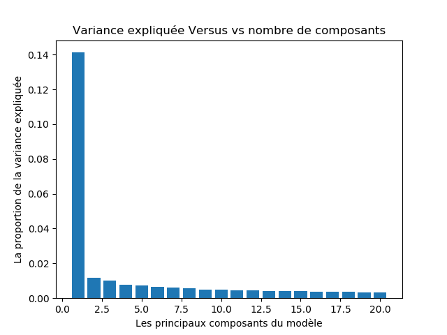

```python
#On applique un PCA sur le dataset

# On commence par obsever la variance expliquée par rapport au nombre de composants
#On part de 20 composantes car
%matplotlib notebook
import matplotlib.pyplot as plt
plt.rcParams.update({'figure.max_open_warning': 0})

import pandas as pd
from sklearn.preprocessing import StandardScaler
from sklearn.decomposition import PCA
import matplotlib.pyplot as plt

X=pd.DataFrame(np.concatenate((FeaFR,FeaEN), axis=0))
X_transf = StandardScaler().fit(X).transform(X)
ACP=PCA(20).fit(X_transf)

plt.bar(range(1, ACP.n_components_ + 1),  ACP.explained_variance_ratio_)
plt.title("Variance expliquée Versus vs nombre de composants")
plt.xlabel('Les principaux composants du modèle')
plt.ylabel('La proportion de la variance expliquée')
plt.show()
```

Parmis les 20 composantes, nous remarquons que 3 composantes nous permettent d'expliquer environ 16% de la variance. Après, cela, on remarque pour le reste des composantes que la valeur de la variance expliquée est faible. Nous allons donc, dans un premier temps, réaliser l'ACP sur trois variables et observer le résultat.

```python
# CACP avec réduction des dimensions à 3
X_ACP = PCA(n_components = 3).fit_transform(X_transf)

#Split du date set en données d'entrainement et données de test sur X transformé
#X1_train X_train transforme avec ACP
X1_train, X1_test, y_train, y_test = train_test_split(X_ACP, y, random_state=0)
```

```python
#On entraine la classification avec ridge et on definie l'hyperparamètre

model = LogisticRegression(penalty='l2')
grid_values = {'C': [10, 100]}
grid = GridSearchCV(model, param_grid = grid_values, scoring = 'accuracy',cv=5).fit(X1_train, y_train)
print("Classification Ridge: ",y_train," Meilleur paramètre=",grid.best_params_)   #MODIF grid au lieu de grid1
print("Accuracy sur les donneés de test:",round(grid.score(X1_train,y_train),5),"\n",\
      "Accuracy sur les données d'entrainement:",round(grid.score(X1_test,y_test),5),"\n")
```

```
Classification Ridge:  [1. 0. 0. ... 1. 0. 0.]  Meilleur paramètre= {'C': 10}
Accuracy sur les donneés de test: 1.0
 Accuracy sur les données d'entrainement: 1.0
```

```python
#Matrice de confusion
conf_mat=confusion_matrix(y_test, grid.predict(X1_test))
```

[figure not shown]

```python
import seaborn as sns
fig, _ = plt.subplots(figsize=(5, 5))
plt.title('Matrice de confusion logistique ridge avec ACP');
sns.heatmap(conf_mat, annot=True,  fmt='')
```

### Visualisation de la separation de classe

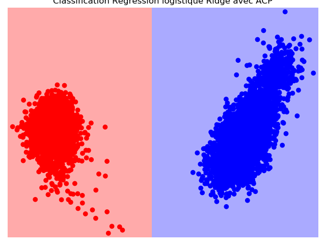

```python
X1 = X_ACP[:,0:2]  # Visualisation des classes en utilisant les deux premiers features
y = y
plot_estimator(grid,X1,y)
plt.title('Classification Regression logistique Ridge avec ACP')
```

La réduction de composantes nous a permis de ramener le problème à seulement 3 variables au lieu de 702 composantes. Les performances de prédiction excellentes (100% de classement correct).

## Questions:

- 1. Réaliser une classification binaire en utilisant les SVM à noyau (comparer les performances obtenus avec un noyau Gaussien (rbf) et un noyau polynomial

### 1.1.5 Classification binaire en utilisant les SVM à noyau

#### SVM avec le noyeau Gaussien

```python
from sklearn import model_selection

# on definit une grille de paramètres C et gamma les hyperparamètres
#param_grid = {'C': C_range, 'gamma': gamma_range}
param_grid = {'C': [1, 10, 100, 1000], 'gamma': [0.001, 0.0001], 'kernel': ['rbf']}

# initialiser une recherche sur grille
grid = model_selection.GridSearchCV(SVC(kernel='rbf'),
                                    param_grid,
                                    cv=5, # 5 folds de validation croisée
                                    scoring='accuracy')
# faire tourner la recherche sur grille
grid.fit(X_train, y_train)

# afficher les paramètres optimaux
print("SVM noyau gaussien  ",y_train," bestparam=",grid.best_params_)
print("Accuracy sur la base d'entrainement:",round(grid.score(X_train,y_train),5)," ",\
      "Accuracy sur la base de test:",round(grid.score(X_test,y_test),5),"\n")
print("The optimal parameters are {} with a score of {:.2f}".format(grid.best_params_, grid.best_score_))
```

```
SVM noyau gaussien   [1. 0. 0. ... 1. 0. 0.]  bestparam= {'C': 1, 'gamma': 0.0001, 'kernel': 'rbf'}
Accuracy sur la base d'entrainement: 1.0   Accuracy sur la base de test: 1.0

The optimal parameters are {'C': 1, 'gamma': 0.0001, 'kernel': 'rbf'} with a score of 1.00
```

#### SVC avec noyau polynomial

```python
#Tuning du modèle Polynomiale
from sklearn import model_selection

# grille de paramètres
#param_grid = {'C': C_range, 'gamma': gamma_range}
param_grid = {'degree': [1, 2,3], 'gamma': [0.001, 0.0001], 'kernel': ['poly']}

# initialiser une recherche sur grille
grid = model_selection.GridSearchCV(SVC(kernel='poly'),
                                    param_grid,
                                    cv=5, # 5 folds de validation croisée
                                    scoring='accuracy')
# faire tourner la recherche sur grille
grid.fit(X_train, y_train)

# afficher les paramètres optimaux
print("SVM noyau polynomial  ",y_train," bestparam=",grid.best_params_)
print("Accuracy sur la base d'entrainement:",round(grid.score(X_train,y_train),5)," ",\
      "Accuracy sur la base de test:",round(grid.score(X_test,y_test),5),"\n")
print("The optimal parameters are {} with a score of {:.2f}".format(grid.best_params_, grid.best_score_))
```

```
SVM noyau polynomial   [1. 0. 0. ... 1. 0. 0.]  bestparam= {'degree': 1, 'gamma': 0.001, 'kernel': 'poly'}
Accuracy sur la base d'entrainement: 1.0   Accuracy sur la base de test: 1.0

The optimal parameters are {'degree': 1, 'gamma': 0.001, 'kernel': 'poly'} with a score of 1.00
```

Les deux modèles SVM avec noyau polynomial et Gaussien permettent tous de faire une excellente classification binaire des langues français et anglais.

### 1.1.6 SVM à noyau avec KernelPCA

```python
##ACP non lineaire, KernelPCA
```

```python
from sklearn.decomposition import KernelPCA
#Standardisation de X
X=pd.DataFrame(np.concatenate((FeaFR,FeaEN), axis=0))
X_transf = StandardScaler().fit(X).transform(X)
transformer = KernelPCA(n_components=2, kernel='rbf')
X_kACP = transformer.fit_transform(X_transf)
```

```python
#X1_train X_train transforme avec ACP
X2_train, X2_test, y_train, y_test = train_test_split(X_kACP, y, random_state=0)
```

```python
SVM_gaussien_acp=SVC(kernel='rbf', C=1, gamma=0.0001).fit(X2_train,y_train)
print("Accuracy sur la base d'entrainement:",round(SVM_gaussien_acp.score(X2_train,y_train),5)," ",\
      "Accuracy sur la base de test:",round(SVM_gaussien_acp.score(X2_test,y_test),5),"\n")
```

```
Accuracy sur la base d'entrainement: 0.50344   Accuracy sur la base de test: 0.51201
```

On constate ici que le SVM à noyeau Gaussien avec le KernePCA ne permet pas de faire une classification correcte des deux langues. En effet, on a un très faible taux de précison 50% environ sur les données d'entrainement et sur les données de test.

## Questions:

- 1. Sur la base des résultats précédents, quelle est la méthode linéaire la plus adaptée à ce problème de classification

### Commentaires :

Le problème de classification des deux langues choisies(Français et Anglais) est en somme un problème simple pouvant être très correctement résolu à l'aide d'un modèle linéaire. En effet, une fréquence d'un certain nombre de lettres permet de caractériser correctement une langue.

Il apparait donc que parmis les modèles linéaires, un des modèles adaptés est la régression logistique Ridge avec ACP. En effet, le modèle linéaire permet également de faire un important gain en temps d'exécution du modèle.

### 1.2. Classification Français/Espagnol

Après l'étude de la classification de deux langues de familles différentes, nous allons faire une brève étude classification de langue de même famille. Dans ce cas présent, nous avons choisis de classer le français et l'espagnol

```python
# Définition de la variable y à prédire
#concatenation des y de FR et EN
y = np.concatenate((np.zeros((len(FeaFR))), np.ones((len(FeaES)))))
#concatenation des features des deux langues FeaFR et FeaEN
X = np.concatenate((FeaFR, FeaES))
#Verification de la concatenation
X.shape
```

```
(8437, 702)
```

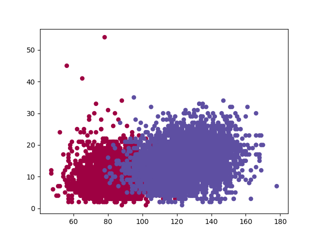

```python
#Visualisation des deux classes avec les deux premiers features
%matplotlib notebook
import matplotlib.pyplot as plt

plt.scatter(X[:,0], X[:,1], s=30, c=y, cmap=plt.cm.Spectral)
```

Les features 'a''t 'b' pris au hasard ne permettent pas de séparer les deux classes.

```python
#Split du dataset en jeu de  données d'entrainement et données de validation du modèle
from sklearn.model_selection import train_test_split
X_train, X_test, y_train, y_test = train_test_split(X, y, random_state=0)
```

```python
#Entrainement du modèle avec Gridsearch.
#Gridsearch permet de faire une recherche exhaustive sur les valeurs de paramètres spécifiées pour un estimateur.
#Les paramètres de l'estimateur utilisé pour appliquer ces méthodes sont optimisés par une recherche croisée validée sur une grille de paramètres.
#On fait une validation croisée égale à 5.


model = LogisticRegression(penalty='l2')
# Le choix est porté sur la classification à l'aide de la régression logistique avec régularisation : norme l2 (Ridge)
##Ajout ZA, 3 paramètres, 1, 0.1 et 0.001, 0.0001
#grid_values = {'C': [10, 100]}
grid_values = {'C': [0.0001,0.001,0.01,0.1,1,10, 100]}
grid = GridSearchCV(model, param_grid = grid_values, scoring = 'accuracy',cv=5).fit(X_train, y_train)
print("Classification Ridge: ",y_train," Meilleur paramètre=",grid.best_params_)
print("Accuracy sur la base d'entrainement:",round(grid.score(X_train,y_train),5)," ",\
      "Accuracy sur la base de test:",round(grid.score(X_test,y_test),5),"\n")
```

```
Classification Ridge:  [1. 1. 1. ... 1. 0. 0.]  Meilleur paramètre= {'C': 0.0001}
Accuracy sur la base d'entrainement: 1.0   Accuracy sur la base de test: 1.0
```

```python
result=pd.DataFrame(grid.cv_results_)
result
```

|  | mean_fit_time | std_fit_time | mean_score_time | std_score_time | param_C | params | split0_test_score | split1_test_score | split2_test_score | split3_test_score | split4_test_score | mean_test_score | std_test_score | rank_test_score |
| --- | --- | --- | --- | --- | --- | --- | --- | --- | --- | --- | --- | --- | --- | --- |
| 0 | 0.278547 | 0.006362 | 0.009283 | 7.292863e-04 | 0.0001 | {'C': 0.0001} | 1.0 | 1.0 | 1.0 | 1.0 | 1.0 | 1.0 | 0.0 | 1 |
| 1 | 0.365983 | 0.033408 | 0.010492 | 1.374021e-03 | 0.001 | {'C': 0.001} | 1.0 | 1.0 | 1.0 | 1.0 | 1.0 | 1.0 | 0.0 | 1 |
| 2 | 0.349056 | 0.015468 | 0.009965 | 8.850969e-04 | 0.01 | {'C': 0.01} | 1.0 | 1.0 | 1.0 | 1.0 | 1.0 | 1.0 | 0.0 | 1 |
| 3 | 0.322337 | 0.012384 | 0.009575 | 4.890480e-04 | 0.1 | {'C': 0.1} | 1.0 | 1.0 | 1.0 | 1.0 | 1.0 | 1.0 | 0.0 | 1 |
| 4 | 0.331314 | 0.020510 | 0.010172 | 7.458689e-04 | 1 | {'C': 1} | 1.0 | 1.0 | 1.0 | 1.0 | 1.0 | 1.0 | 0.0 | 1 |
| 5 | 0.328124 | 0.017873 | 0.009974 | 5.917394e-07 | 10 | {'C': 10} | 1.0 | 1.0 | 1.0 | 1.0 | 1.0 | 1.0 | 0.0 | 1 |
| 6 | 0.328999 | 0.031293 | 0.010691 | 2.074474e-03 | 100 | {'C': 100} | 1.0 | 1.0 | 1.0 | 1.0 | 1.0 | 1.0 | 0.0 | 1 |

```python
#Matrice de confusion
conf_mat=confusion_matrix(y_test, grid.predict(X_test))
```

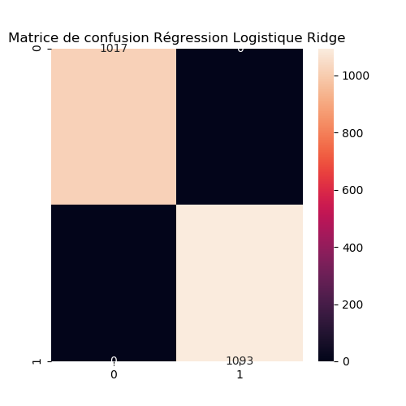

```python
import seaborn as sns
fig, _ = plt.subplots(figsize=(5, 5))
plt.title('Matrice de confusion Régression Logistique Ridge');
sns.heatmap(conf_mat, annot=True,  fmt='')
```

```python
# Sélection de features les plus importants pour la
from sklearn.feature_selection import SelectFromModel

estimator = LogisticRegression(penalty='l2',C=0.001).fit(X_train,y_train)
model = SelectFromModel(estimator, prefit=True)
model.estimator.coef_[0]
index=model.get_support(indices=True)

print('Nombre de features selectionés  ' +  str(len(index)))
coef=model.estimator.coef_[0]
features=[]
estimation=[]
indice=[]
for i in range (0, len(index)):
    features.append(colnames[index[i]])
    estimation.append(abs(coef[index[i]]))
    indice.append(index[i])
```

```
Nombre de features selectionés  172
```

```python
dataset = list(zip(indice,features,estimation))
feature_importance=pd.DataFrame(data=dataset, columns=['indice','features','coef'])
sorted_feat=feature_importance.sort_values(by=['coef'], ascending=False)
print('Les features les plus importantes pour le modèle regression Logistique Ridge')
sorted_feat
```

```
Les features les plus importantes pour le modèle regression Logistique Ridge
```

|  | indice | features | coef |
| --- | --- | --- | --- |
| 12 | 14 | o | 0.075057 |
| 0 | 0 | a | 0.056050 |
| 3 | 4 | e | 0.038095 |
| 18 | 20 | u | 0.037627 |
| 30 | 34 | ai | 0.034960 |
| ... | ... | ... | ... |
| 90 | 324 | lm | 0.002669 |
| 169 | 653 | yd | 0.002659 |
| 87 | 280 | ju | 0.002653 |
| 124 | 412 | ow | 0.002641 |
| 137 | 494 | sa | 0.002633 |

172 rows × 3 columns

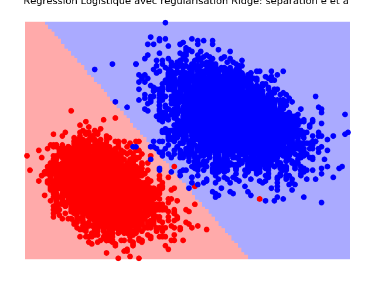

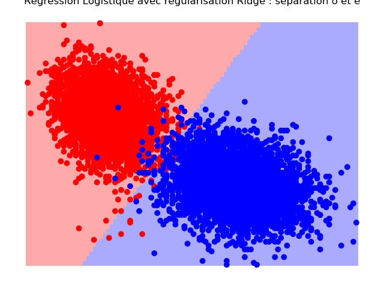

```python
#features 'o' et 'a'
X1 = X[:,[14,0]]
y = y

#Appel à la fonction plot pour visualiser la frontière de séparation
plot_estimator(grid,X1,y)
plt.title('Regression Logistique avec régularisation Ridge: separation e et a ')
X2 = X[:,[14,4]]  # Features : o et e
plot_estimator(grid,X2,y)
plt.title('Regression Logistique avec régularisation Ridge : separation o et e')
```

#### Nous allons affiner les résultats de cette classification avec une PCA

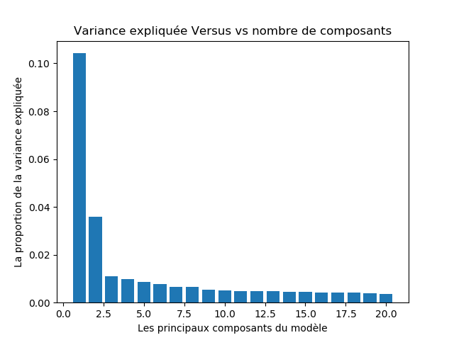

```python
%matplotlib notebook
import matplotlib.pyplot as plt
plt.rcParams.update({'figure.max_open_warning': 0})

import pandas as pd
from sklearn.preprocessing import StandardScaler
from sklearn.decomposition import PCA
import matplotlib.pyplot as plt

X=pd.DataFrame(np.concatenate((FeaFR,FeaES), axis=0))
X_transf = StandardScaler().fit(X).transform(X)
ACP=PCA(20).fit(X_transf)

plt.bar(range(1, ACP.n_components_ + 1),  ACP.explained_variance_ratio_)
plt.title("Variance expliquée Versus vs nombre de composants")
plt.xlabel('Les principaux composants du modèle')
plt.ylabel('La proportion de la variance expliquée')
plt.show()
```

```python
# Au vu des résultats du graphique précédent,
#Nous débutons les analyses ACPC avec réduction des dimensions à 3
X_ACP = PCA(n_components = 3).fit_transform(X_transf)

#Split du date set en données d'entrainement et données de test sur X transformé
#X1_train X_train transforme avec ACP
X1_train, X1_test, y_train, y_test = train_test_split(X_ACP, y, random_state=0)
```

```python
#On entraine la classification avec ridge et on definie l'hyperparamètre

model = LogisticRegression(penalty='l2')
grid_values = {'C': [10, 100]}
grid = GridSearchCV(model, param_grid = grid_values, scoring = 'accuracy',cv=5).fit(X1_train, y_train)
print("Classification Ridge: ",y_train," Meilleur paramètre=",grid.best_params_)   #MODIF grid au lieu de grid1
print("Accuracy sur les donneés de test:",round(grid.score(X1_train,y_train),5),"\n",\
      "Accuracy sur les données d'entrainement:",round(grid.score(X1_test,y_test),5),"\n")
```

```
Classification Ridge:  [1. 1. 1. ... 1. 0. 0.]  Meilleur paramètre= {'C': 10}
Accuracy sur les donneés de test: 1.0
 Accuracy sur les données d'entrainement: 1.0
```

```python
#Matrice de confusion
conf_mat=confusion_matrix(y_test, grid.predict(X1_test))
```

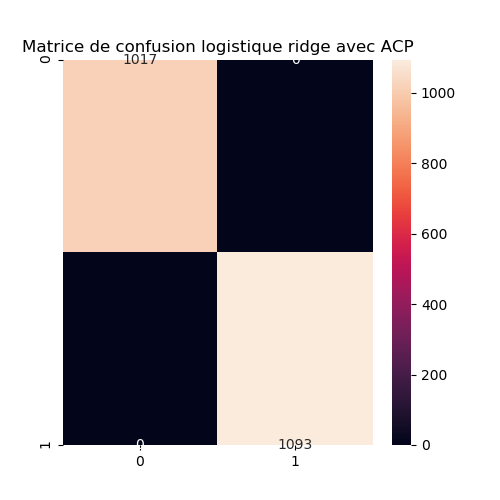

```python
import seaborn as sns
fig, _ = plt.subplots(figsize=(5, 5))
plt.title('Matrice de confusion logistique ridge avec ACP');
sns.heatmap(conf_mat, annot=True,  fmt='')
```

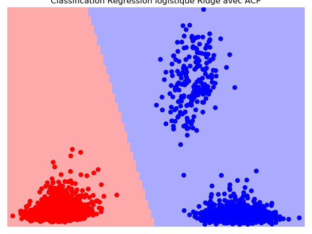

```python
X1 = X_ACP[:,0:2]  # Visualisation des classes en utilisant les deux premiers features
y = y
plot_estimator(grid,X1,y)
plt.title('Classification Regression logistique Ridge avec ACP')
```

La classification Regression logistique Ridge avec ACP permet de faire une excellente classification des deux langues latines Français et espagnol

## Questions:

- 1. Enfin, mettre en place une méthode (de votre choix) de classification multi-classe;
  - Donner la matrice de confusion et indiquer les languages les plus difficile à distinguer.

## 2. Classification Multiclasses

Pour la classification multi classes nous utiliserons une ACP pour réduire les dimensions et les hyperparamètres définis pour les différents modèles. Grâce à la visulisation des données en 2 dimension, nous avons remarqué qu'il est possible de faire la classification à l'aide de deux variables les plus significatives, donc pour les classifications à 4 classes nous réduisons les dimensions à 2 composantes. Nous n'utiliserons pas les réductions de dimensions non linéaires car cela n'a pas donné de bons résultats pour la classification de 2 langues

```python
# Définition de la variable à prédire y
#4 Classes
# Français : 0
# Anglais :1
# Espagnol :2
# Allemand :3
y = np.concatenate((np.zeros((len(FeaFR))), np.ones((len(FeaEN))), 2*np.ones((len(FeaES))), 3*np.ones((len(FeaDE)))))

y.shape

#concatenation des features des deux langues FeaFR et FeaEN
X = np.concatenate((FeaFR, FeaEN, FeaES, FeaDE))


#Verification de la dimension totale après concatenation
X.shape
```

```
(16975, 702)
```

```python
y.shape
```

```
(16975,)
```

## Visualisation des données

#### Vue des données en 2 dimensions avant classification

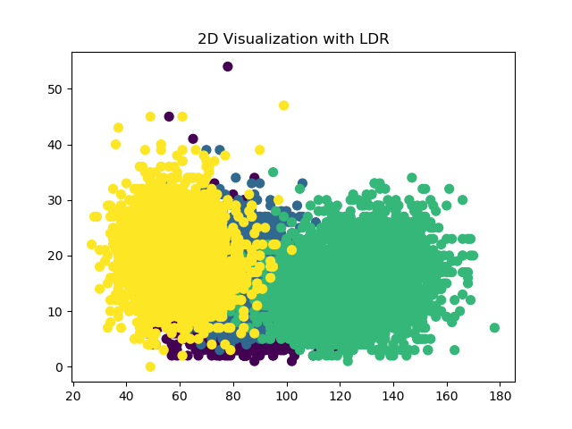

```python
plt.figure(6)
size_vertex_plot = 50

n = X.shape[0]
plt.scatter(X[:,0], X[:,1], s=size_vertex_plot*np.ones(n), c=y)
plt.title('2D Visualization with LDR')
plt.show()
```

#### Visualisation en 3 dimensions avant classification

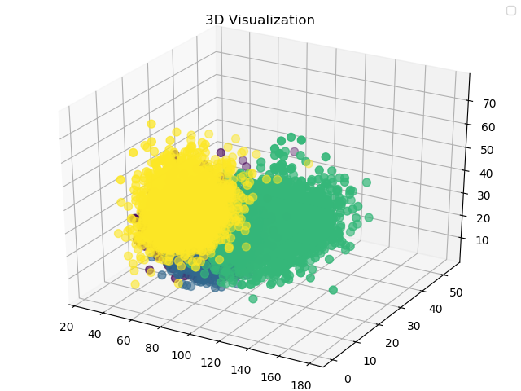

```
No handles with labels found to put in legend.
```

```python
fig = pylab.figure(7)
ax = Axes3D(fig)
size_vertex_plot = 50
ax.scatter(X[:,0], X[:,1], X[:,2], s=size_vertex_plot*np.ones(n), c=y)
plt.title('3D Visualization')
pyplot.show()
pyplot.legend()
```

### 2.1 Regression logistique ridge avec ACP

```python
import pandas as pd
from sklearn.preprocessing import StandardScaler
from sklearn.decomposition import PCA
import matplotlib.pyplot as plt

X_normalise = StandardScaler().fit(X).transform(X)
X_ACP = PCA(n_components = 2).fit_transform(X_normalise)
```

```python
from sklearn.model_selection import train_test_split

X2_train, X2_test, y_train, y_test = train_test_split(X_ACP, y, random_state=0)
```

```
Accuracy ratio sur la base apprentissage: 0.997 (ovr)
Accuracy ratio sur la base de test: 0.995 (ovr)
Matrice de confusion Regression Logistique (ovr)


[[ 995    0    5    4]
 [   0 1054    0    0]
 [   3    2 1089    0]
 [   5    1    0 1086]]
```

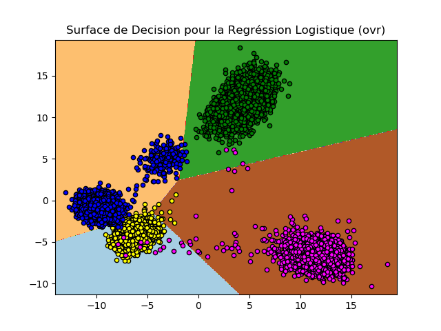

```
Accuracy ratio sur la base apprentissage: 0.999 (multinomial)
Accuracy ratio sur la base de test: 0.998 (multinomial)
Matrice de confusion Regression Logistique (multinomial)


[[1004    0    0    0]
 [   0 1054    0    0]
 [   4    0 1090    0]
 [   5    0    0 1087]]
```

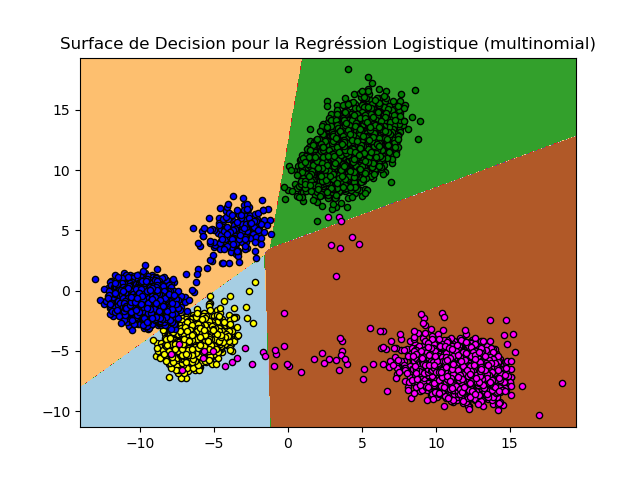

```
jaune= Français vert= Anglais Bleu= Espagnol  Magenta= Allemand
```

```python
#Plot des limites de décisions pour une regression logistique multinomiale et one versus all
#On ramène le problème à 2 dimensions avec le PCA

for multi_class in ('ovr', 'multinomial'):
    Mod = LogisticRegression(penalty='l2',C=0.1,solver='sag', max_iter=100, random_state=0,
                             multi_class=multi_class).fit(X2_train, y_train)

   # print the training scores
    print("Accuracy ratio sur la base apprentissage: %.3f (%s)" % (Mod.score(X2_train, y_train), multi_class))
    print("Accuracy ratio sur la base de test: %.3f (%s)" % (Mod.score(X2_test, y_test), multi_class))

    y_pred = Mod.predict(X2_test)

    #Affichage de la matrice de confusion
    print("Matrice de confusion Regression Logistique (%s)" % multi_class )
    print("\n")
    print(confusion_matrix(y_test,y_pred))

    # create a mesh to plot in
    h = .05  # step size in the mesh
    x_min, x_max = X_ACP[:, 0].min() - 1, X_ACP[:, 0].max() + 1
    y_min, y_max = X_ACP[:, 1].min() - 1, X_ACP[:, 1].max() + 1
    xx, yy = np.meshgrid(np.arange(x_min, x_max, h),
                         np.arange(y_min, y_max, h))

    # Plot the des frontières de décision

    Z = Mod.predict(np.c_[xx.ravel(), yy.ravel()])

    # Put the result into a color plot
    Z = Z.reshape(xx.shape)
    plt.figure()
    plt.contourf(xx, yy, Z, cmap=plt.cm.Paired)
    plt.title("Surface de Decision pour la Regréssion Logistique (%s)" % multi_class)
    plt.axis('tight')

    # Plot also the training points
    colors = ["yellow","green","blue","magenta"]
    for i, color in zip(Mod.classes_, colors):
        idx = np.where(y == i)
        plt.scatter(X_ACP[idx, 0], X_ACP[idx, 1], c=color, cmap=plt.cm.Paired,
                    edgecolor='black', s=20)

    # Plot the three one-against-all classifiers
    xmin, xmax = plt.xlim()
    ymin, ymax = plt.ylim()
    coef = Mod.coef_
    intercept = Mod.intercept_

print("jaune= Français vert= Anglais Bleu= Espagnol  Magenta= Allemand")
plt.show()
```

### Commentaires :

Au vu des deux graphes, on remarque que :

1. Pour le cas présent, la méthode de classification multimoniale permet de mieux détérminer les frontières de séparation différentes classes par rapport à la méthode one versus all.
1. Pour les deux méthodes, la frontière entre l'espagnol et le français n'est pas bien faite.
2. Un certain nombre (faible) d'instances allemandes sont classés dans la zone de la langue Française et anglaise
3. Pour la matrice de confusion, 4 et 5 occurences mal classés respectivement pour l'espagnol et allemand, pour la méthodologie Classification 2 à 2

### 2.2 SVM linéaire pour classer les 4 langues

Les hyperparamètres C sont ceux définit pour le modèle SVM linéaire à deux classes, et réduction de dimension à 2 composantes

```
Accuracy ratio sur la base apprentissage: 0.991 (ovr)
Accuracy ratio sur la base de test: 0.989 (ovr)
Matrice de confusion SVM linéaire (ovr)


[[ 998    1    4    1]
 [   0 1054    0    0]
 [   3   31 1060    0]
 [   4    2    0 1086]]
```

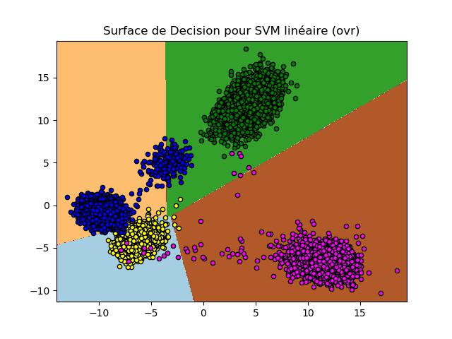

```
Accuracy ratio sur la base apprentissage: 0.996 (crammer_singer)
Accuracy ratio sur la base de test: 0.996 (crammer_singer)
Matrice de confusion SVM linéaire (crammer_singer)


[[1000    0    4    0]
 [   0 1054    0    0]
 [   4    0 1090    0]
 [   8    2    0 1082]]
```

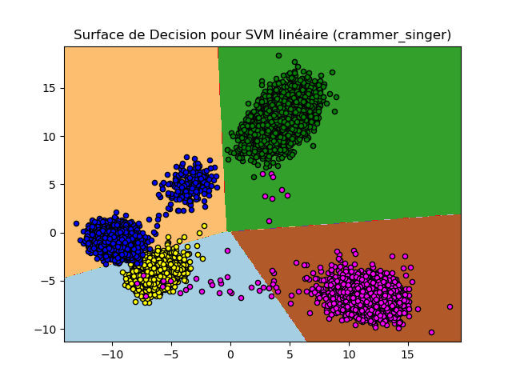

```
Jaune= Français vert= Anglais Bleu= Espagnol  Magenta= Allemand
```

```python
#Plot des limites de décisions pour une regression logistique multinomiale et one versus all
#On ramène le problème à 2 dimensions avec le PCA



for multi_class in ('ovr', 'crammer_singer'):   #correction crammer_singer au lieu de multinomial

    Mod=LinearSVC(C=0.001, multi_class=multi_class, random_state=0, max_iter=1000).fit(X2_train, y_train)
    # print the training scores
    print("Accuracy ratio sur la base apprentissage: %.3f (%s)" % (Mod.score(X2_train, y_train), multi_class))
    print("Accuracy ratio sur la base de test: %.3f (%s)" % (Mod.score(X2_test, y_test), multi_class))
   # prediction test
    y_pred = Mod.predict(X2_test)

    #Affichage de la matrice de confusion
    print("Matrice de confusion SVM linéaire (%s)" % multi_class )
    print("\n")
    print(confusion_matrix(y_test,y_pred))

    # create a mesh to plot in
    h = .05  # step size in the mesh
    x_min, x_max = X_ACP[:, 0].min() - 1, X_ACP[:, 0].max() + 1
    y_min, y_max = X_ACP[:, 1].min() - 1, X_ACP[:, 1].max() + 1
    xx, yy = np.meshgrid(np.arange(x_min, x_max, h),
                         np.arange(y_min, y_max, h))

    # Plot the des frontières de décision

    Z = Mod.predict(np.c_[xx.ravel(), yy.ravel()])

    # Put the result into a color plot
    Z = Z.reshape(xx.shape)
    plt.figure()
    plt.contourf(xx, yy, Z, cmap=plt.cm.Paired)
    plt.title("Surface de Decision pour SVM linéaire (%s)" % multi_class)
    plt.axis('tight')

    # Plot also the training points
    colors = ["yellow","green","blue","magenta"]
    for i, color in zip(Mod.classes_, colors):
        idx = np.where(y == i)
        plt.scatter(X_ACP[idx, 0], X_ACP[idx, 1], c=color, cmap=plt.cm.Paired,
                    edgecolor='black', s=20)

    # Plot the three one-against-all classifiers
    xmin, xmax = plt.xlim()
    ymin, ymax = plt.ylim()
    coef = Mod.coef_
    intercept = Mod.intercept_

plt.show()
print("Jaune= Français vert= Anglais Bleu= Espagnol  Magenta= Allemand")
```

### 3- SVM à noyau gaussien pour classer les 4 langues

Nous utiliserons les mêmes hyper paramètres définis lors de la classification à deux classes

```
Accuracy ratio sur la base apprentissage: 0.997 (ovr)
Accuracy ratio sur la base de test: 0.995 (ovr)
Matrice de confusion SVM à noyau gaussien (ovr)


[[1004    0    0    0]
 [   0 1054    0    0]
 [   4    7 1083    0]
 [   7    2    0 1083]]
```

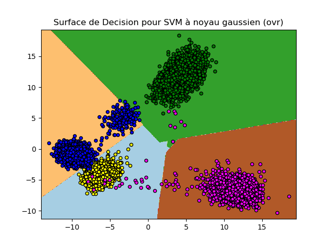

```
Accuracy ratio sur la base apprentissage: 0.997 (crammer_singer)
Accuracy ratio sur la base de test: 0.995 (crammer_singer)
Matrice de confusion SVM à noyau gaussien (crammer_singer)


[[1004    0    0    0]
 [   0 1054    0    0]
 [   4    7 1083    0]
 [   7    2    0 1083]]
```

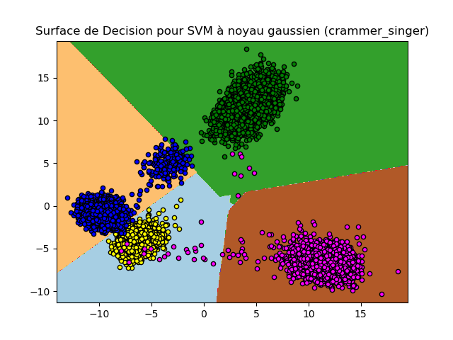

```
Jaune= Français vert= Anglais Bleu= Espagnol  Magenta= Allemand
```

```python
#Plot des limites de décisions pour SVM non linéaire multinomiale et one versus all
#On ramène le problème à 2 dimensions avec le PCA

from sklearn.svm import SVC
from sklearn.metrics import confusion_matrix

#boucle sur les type de classifications ovr one vs all et classification deux pas deux
for multi_class in ('ovr', 'crammer_singer'):
  #svm a noyau gaussien
    Mod=SVC(kernel='rbf',gamma=0.0001, C=1 ,random_state=0, max_iter=1000).fit(X2_train, y_train)

    # print the accuracy ratio
    print("Accuracy ratio sur la base apprentissage: %.3f (%s)" % (Mod.score(X2_train, y_train), multi_class))
    print("Accuracy ratio sur la base de test: %.3f (%s)" % (Mod.score(X2_test, y_test), multi_class))

    y_pred = Mod.predict(X2_test)

    #Affichage de la matrice de confusion
    print("Matrice de confusion SVM à noyau gaussien (%s)" % multi_class )
    print("\n")
    print(confusion_matrix(y_test,y_pred))

    # create a mesh to plot in
    h = .05  # step size in the mesh
    x_min, x_max = X_ACP[:, 0].min() - 1, X_ACP[:, 0].max() + 1
    y_min, y_max = X_ACP[:, 1].min() - 1, X_ACP[:, 1].max() + 1
    xx, yy = np.meshgrid(np.arange(x_min, x_max, h),
                         np.arange(y_min, y_max, h))

    # Plot the des frontières de décision

    Z = Mod.predict(np.c_[xx.ravel(), yy.ravel()])

    # Put the result into a color plot
    Z = Z.reshape(xx.shape)
    plt.figure()
    plt.contourf(xx, yy, Z, cmap=plt.cm.Paired)
    plt.title("Surface de Decision pour SVM à noyau gaussien (%s)" % multi_class)
    plt.axis('tight')

    # Plot also the training points
    colors = ["yellow","green","blue","magenta"]
    for i, color in zip(Mod.classes_, colors):
        idx = np.where(y == i)
        plt.scatter(X_ACP[idx, 0], X_ACP[idx, 1], c=color, cmap=plt.cm.Paired,
                    edgecolor='black', s=20)

    # Plot the three one-against-all classifiers
    xmin, xmax = plt.xlim()
    ymin, ymax = plt.ylim()
    coef = Mod.dual_coef_
    intercept = Mod.intercept_
print("Jaune= Français vert= Anglais Bleu= Espagnol  Magenta= Allemand")
plt.show()
```

### Conclusion Générale :

#### Classifications de 2 langues:

- Les modèles de SVM à noyau donnent des performances d'accuracy ratio excellentes ( proche de 100%) mais prennent un temps de calcul plus long
- Les modèles linéaires de classification sont plus adaptés à cette problématique ou les performances sont proches de 100% et les 2 langues sont bien classées avec moins de temps de calcul
- Avec la réduction de dimension, les perfomances de modèles linéaires sont restées excellentes (proche de 100%).
- Les modèles de SVM à noyau avec réduction de dimension non linéaire (kPCA) donne des performances d'accuracy ratio de 50% loin des performance des modèles linéaires qui ont une performance proche de 100%; cela n'est pas adapté à notre problématique